# GEGVICshine manual

#### 2.5. IC_module

This section contains the predictions of immune cell composition in the tumour microenvironment from RNA-sequencing data. Predictions are made using the `inmmunedeconv` [package](https://github.com/icbi-lab/immunedeconv), which include six prediction algorithms: QUANTISEQ, TIMER, MCP_COUNTER, XCELL, EPIC and CIBERSORT.

- **Summary of predicted immune cell populations**: Table showing the prediction results of each immune cell types by each algorithm per sample with the same format as the other tables commented before. Like them, there is also download button to obtain the full table in a form of a .csv file.

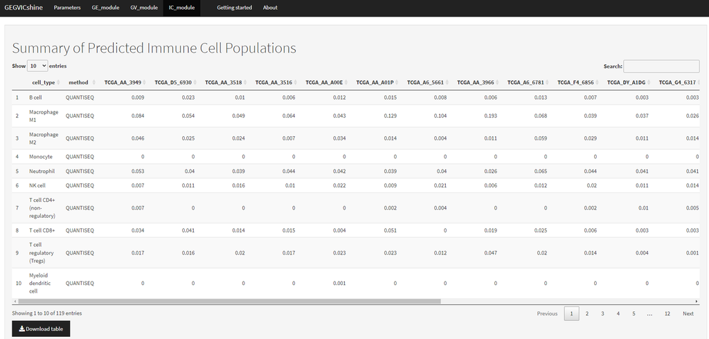

- **Immune composition cell types comparison by groups**: A plot were each immune cell type is compared between sample groups within all the six prediction methods. CIBERSORT result will only be shown if the user specifies a local folder.

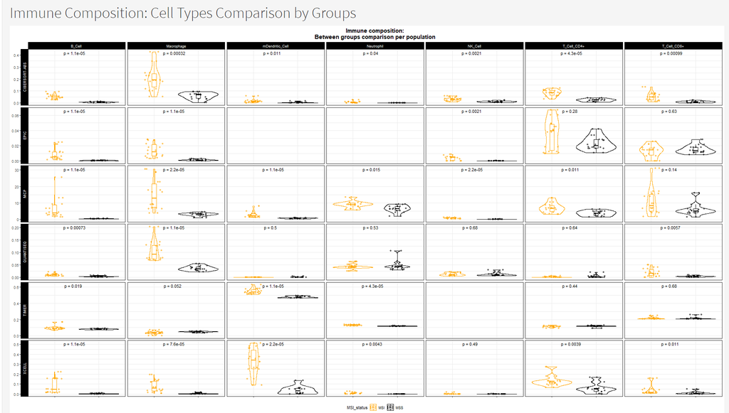

- **Immune composition: Cell types comparison within samples**: A plot were the predicted percentage of each immune cell type is show for each sample. Only CIBERSORT, EPIC and QUANTISEQ methods allow to compare cell types within a sample. CIBERSORT result will only be shown if the user specifies a local folder.

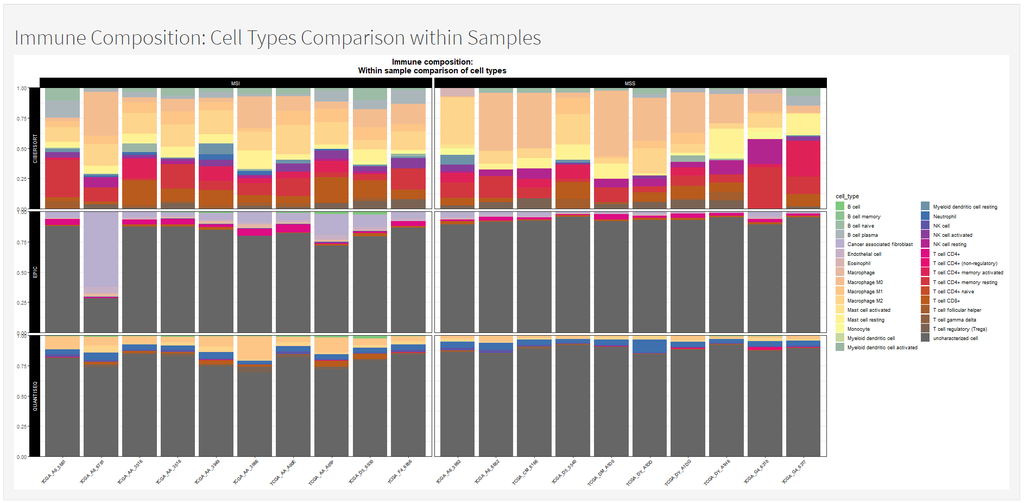

- **Immune Score**: The state of Effector cells (EC), Suppressor cells (SC), Immunomodulators (CP) and MHC molecules (MHC) are shown. All this values are added up to calculate an immunophenoscore (IPS). The table show the corresponding values for each sample. Finally, there is a button to generate a pdf report that will contain an immunophenogram (IPG) per each sample per page. Here we show an example of one of the samples. For further interpretation please visit [The Cancer Immunome Atlas](https://tcia.at/tools/toolsMain).

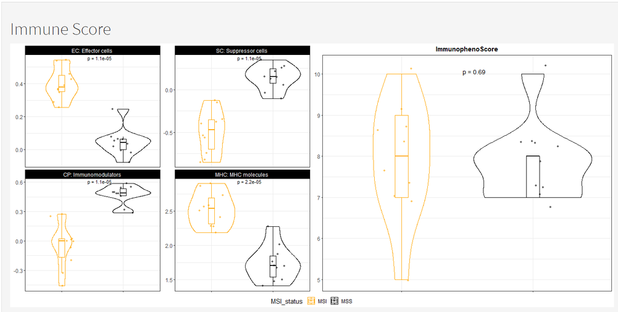

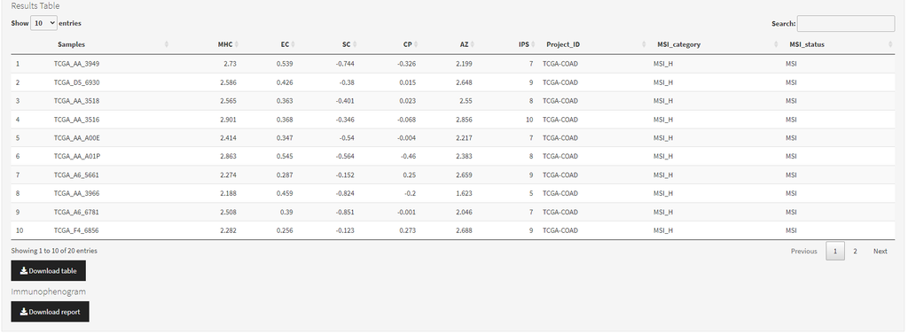

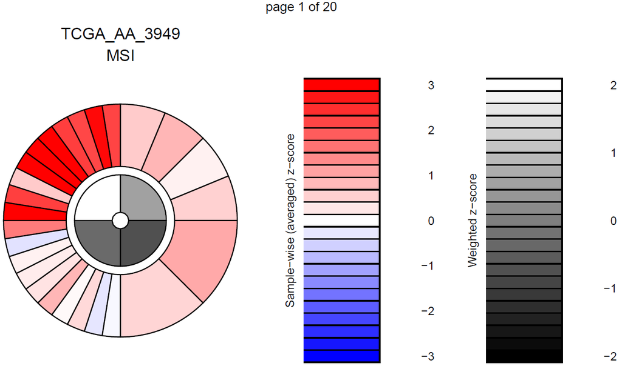